# USP654 Lab 2: Bivariate Regression

Liming Wang

9/25/2017

## RStudio Project

I recommend you organize your data analysis project with RStudio projects. One data analysis project per Studio project. (Stick to a similar practice even if you’re using SPSS.)

Launch RStudio, go to **File/New Project…** menu, select **New Directory** (if you already created your directory, Existing Directory) and **New Project**, type in a directory name and then click then **Create Project** button. You can use “usp654_project” as your directory name or choose a more expressive name.

Some tips of managing your RStudio project: 1. Create a *data* folder inside your project directory for raw data files (never change data files manually). 2. Create a *code* folder inside your project directory for R script. It is better to work with a script file than using the R console for substantial work (for example, your homework or class project). R console is mostly for testing to make sure your scripts work. 3. Create an *output* folder inside your project directory for any outputs from your R scripts you would like to save for later use, which include data, figures, tables, etc. 4. (Optional) Create an *docs* folder inside your project directory for any documents.

More details of the best practice of [Project Management With RStudio](http://swcarpentry.github.io/r-novice-gapminder/02-project-intro/).

## R Package

One of the advantages of R is the thousands packages that extend the functionailities of base R. A major part of learning R is to learn to work with R packages. Besides the base R, we will use a suite of packages named [`tidyverse`](https://www.tidyverse.org/) that covers the whole process of data analysis. To install the `tidyverse` packages, you can use the **Packages** pane or run R function in RStudio’s **Console** pane:

```r
install.packages("tidyverse")
```

To use R packages you have installed, include this line in your script or in the Console:

```r
library("tidyverse")
# Note here the quotation marks are optional and
# it is the same as
library(tidyverse)
```

## Import Data

1. Download the data file for this lab from here and save it to data directory of your RStudio project.
2. What format is the data file in?
3. Import the data in the file into R as a data frame:

```r
my_df <- read_csv("data/mtcars.csv")
my_df
```

```
## # A tibble: 32 x 11
##      mpg   cyl  disp    hp  drat    wt  qsec    vs    am  gear  carb
##    <dbl> <int> <dbl> <int> <dbl> <dbl> <dbl> <int> <int> <int> <int>
##  1  21.0     6 160.0   110  3.90 2.620 16.46     0     1     4     4
##  2  21.0     6 160.0   110  3.90 2.875 17.02     0     1     4     4
##  3  22.8     4 108.0    93  3.85 2.320 18.61     1     1     4     1
##  4  21.4     6 258.0   110  3.08 3.215 19.44     1     0     3     1
##  5  18.7     8 360.0   175  3.15 3.440 17.02     0     0     3     2
##  6  18.1     6 225.0   105  2.76 3.460 20.22     1     0     3     1
##  7  14.3     8 360.0   245  3.21 3.570 15.84     0     0     3     4
##  8  24.4     4 146.7    62  3.69 3.190 20.00     1     0     4     2
##  9  22.8     4 140.8    95  3.92 3.150 22.90     1     0     4     2
## 10  19.2     6 167.6   123  3.92 3.440 18.30     1     0     4     4
## # ... with 22 more rows
```

Of course, the step of import data into your statistic software vary a little by software and by the data format.

More information as of how to import data into R can be found at Import Data

## Descriptive Statistics

### Visualization

1. Visualize a single variable

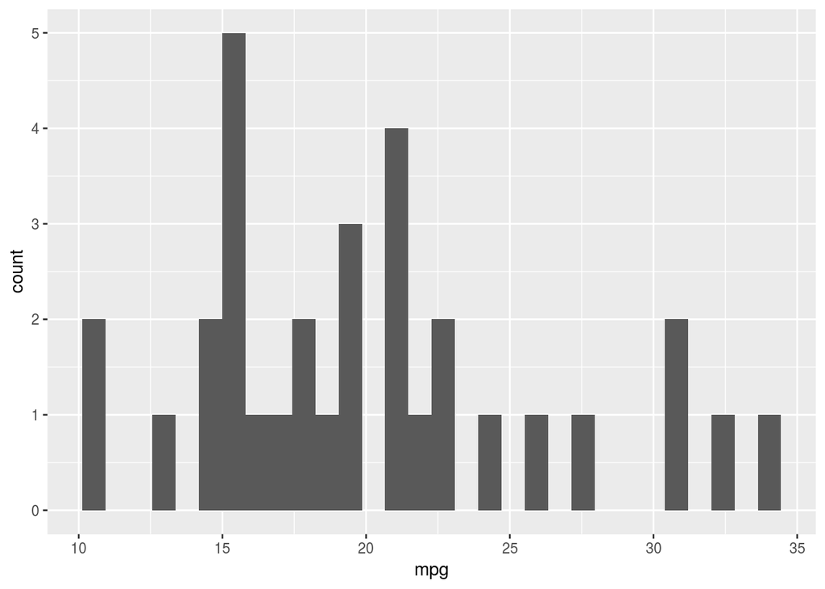

```r
ggplot(my_df, aes(x=mpg)) + geom_histogram()
```

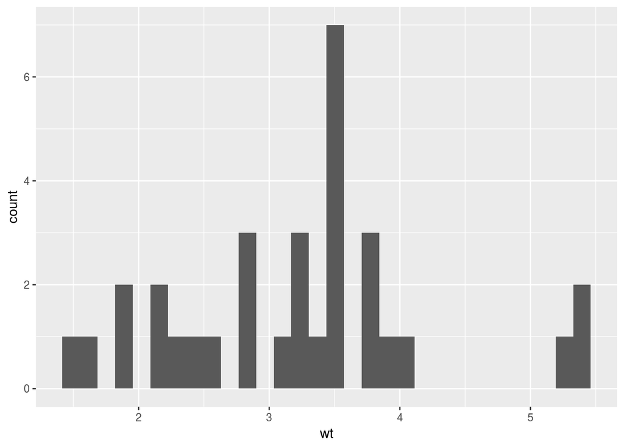

```r
ggplot(my_df, aes(x=wt)) + geom_histogram()
```

2. Visualize a pair of numeric variables

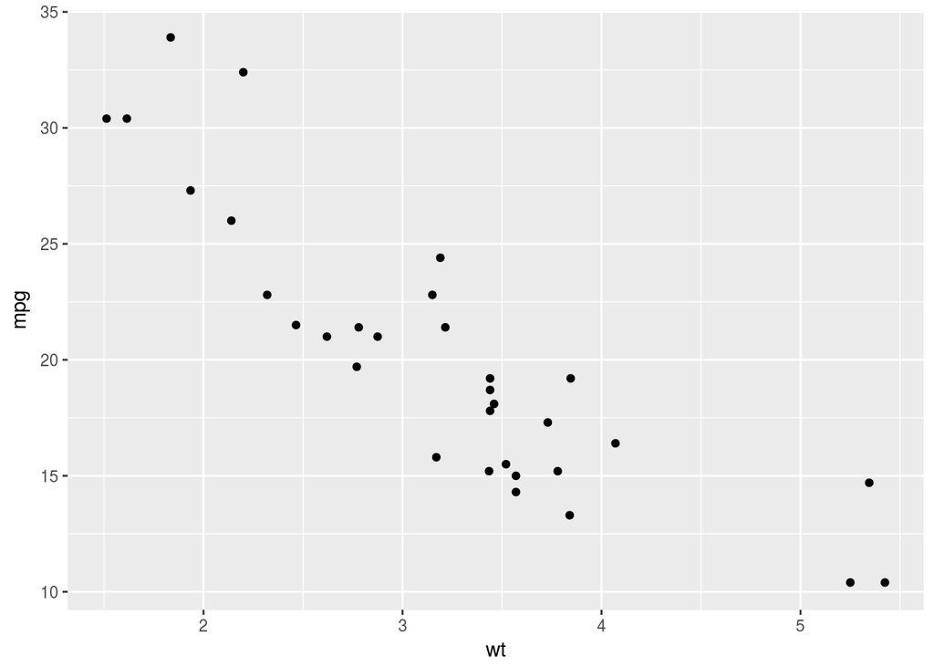

```r
ggplot(my_df, aes(x=wt, y=mpg)) + geom_point()
```

## Correlation

```r
cor(my_df$mpg, my_df$wt)
```

```
## [1] -0.8676594
```

## Regression

In R, run linear regressions with `lm` (short for **l**inear **m**odel):

```r
lm(mpg ~ wt, data=my_df)
```

```
##
## Call:
## lm(formula = mpg ~ wt, data = my_df)
##
## Coefficients:
## (Intercept)           wt
##      37.285       -5.344
```

## More detailed regression results

1. Pass the results from `lm()` to `summary()` for more detailed information:

```r
lm(mpg ~ wt, data=my_df) %>%
  summary
```

```
##
## Call:
## lm(formula = mpg ~ wt, data = my_df)
##
## Residuals:
##     Min      1Q  Median      3Q     Max
## -4.5432 -2.3647 -0.1252  1.4096  6.8727
##
## Coefficients:
##             Estimate Std. Error t value Pr(>|t|)
## (Intercept)  37.2851     1.8776  19.858  < 2e-16 ***
## wt           -5.3445     0.5591  -9.559 1.29e-10 ***
## ---
## Signif. codes:  0 '***' 0.001 '**' 0.01 '*' 0.05 '.' 0.1 ' ' 1
##
## Residual standard error: 3.046 on 30 degrees of freedom
## Multiple R-squared:  0.7528, Adjusted R-squared:  0.7446
## F-statistic: 91.38 on 1 and 30 DF,  p-value: 1.294e-10
```

For better formatting of the results (pretty print), we can use the `texreg` package:

```r
## Install and load texreg package
install.packages("texreg")
library(texreg)

# Pretty print regression results on screen
lm(mpg ~ wt, data=my_df) %>%
  screenreg
```

```
##
## ======================
##              Model 1
## ----------------------
## (Intercept)  37.29 ***
##              (1.88)
## wt           -5.34 ***
##              (0.56)
## ----------------------
## R^2           0.75
## Adj. R^2      0.74
## Num. obs.    32
## RMSE          3.05
## ======================
## *** p < 0.001, ** p < 0.01, * p < 0.05
```

```r
# Save regression results to a html file
lm(mpg ~ wt, data=my_df) %>%
  htmlreg(file="output/lm_mpg-wt.html")
```

## Visualize regression results

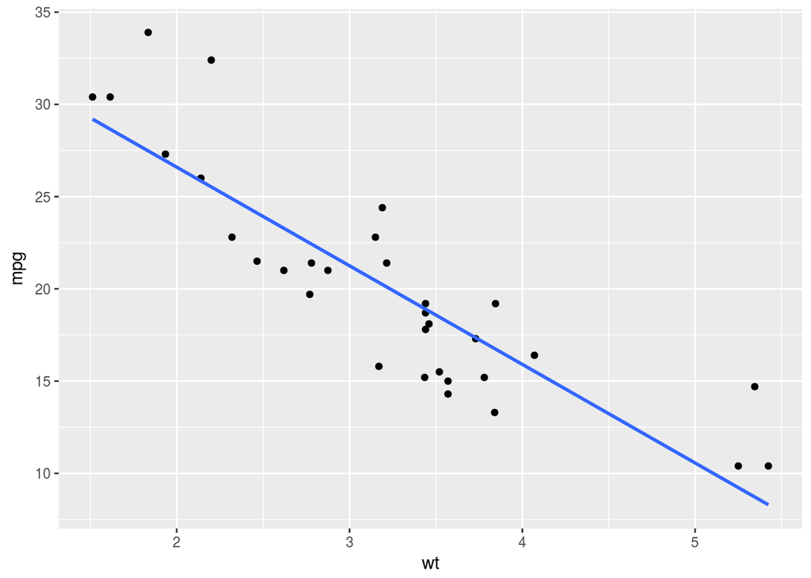

```r
ggplot(my_df, aes(x=wt, y=mpg)) + geom_point() + geom_smooth(method = "lm", se = FALSE)
```

## Diagnostic plots of regression

We will use the `ggfortify` package to generate the diagnostic plots for regression

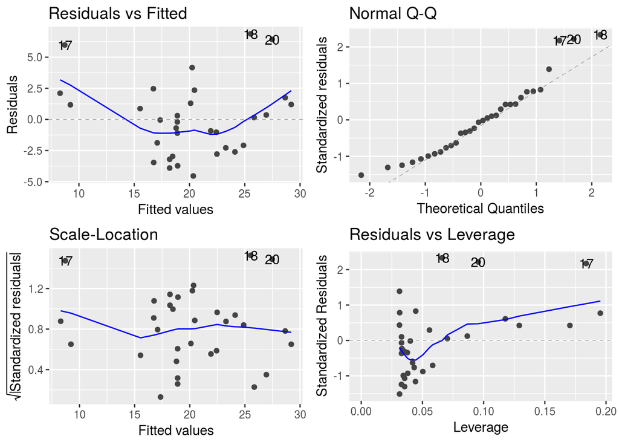

```r
## Install and load ggfortify package
install.packages("ggfortify")
library(ggfortify)

lm(mpg ~ wt, data=my_df) %>%
  autoplot()
```

```r
# Since we need the regression results in many places,
# it would be easier to save it into a R variable
mpg_lm <- lm(mpg ~ wt, data=my_df)

# Save the diagnostic plots as a png file
ggsave("output/mpg_lm_diag.png")
```

## Tasks

1. Create a new RStudio project and create directory structure following the recommendation in [Project Management With RStudio](http://swcarpentry.github.io/r-novice-gapminder/02-project-intro/);
2. Select a dataset from the [Tools and Datasets] section of the course website or use your own dataset, save the dataset in the data folder of your project;
3. Famarlize yourself with your dataset with the data document;
4. Create a script that imports your dataset into R and explores it with descriptive statistics and/or visulization;
5. Choose a dependent variable and a couple of independent variables and run regression models;
6. Create regression plot (scatter plot superimposed with a regression line) & diagnostic plots.

## Resources

- [Introduction to R on Data Camp](https://campus.datacamp.com/courses/free-introduction-to-r/chapter-1-intro-to-basics-1?ex=1): A self-instruction course covering R basics.
- [R coding basics on Software Carpentry](http://swcarpentry.github.io/r-novice-gapminder/), hands-on tutorial on R basics, lesson 4-11.